# Income Classification Project - Summary Report

Fadi Murad

July 19, 2018

### 1. Overview

This is a binary classification problem to predict income with fairly huge and imbalanced dataset (300,000 instances,41 attributes, and 94:6 class ratio). We will build different predictive models and compare their performance in order to choose the best model.

##### Problem Statement

**“Predict the income class of US population”**

The aim for this project is to build a predictive model to determine the income level for people in US. The income levels are binned at below 50K and above 50K.

##### Project Content

I divided this project into 4 sections, the first folder contains data sets while the rest represent the steps of this project and contain the related documents (in RMD and HTML formats) in addition to the supported files.

Below are the 4 sections of our project where you can find the full details:

1. Dataset
2. Data Exploration
3. Data Cleaning and Manipulation
4. Machine Learning

### 2. Data Set

Train set: 199,523 instances and 41 attributes, Test set: 99,762 instances and 41 attributes. You can find train and test sets in csv format with columns names and ready to be loaded.

We’ve taken the data set from UCI Machine Learning Repository, and you can find the original data at: http://archive.ics.uci.edu/ml/machine-learning-databases/census-income-mld/

### 3. Data Exploration

This step includes loading data, prepare data and taking a look at each variable in order to understand the data.

As we mentioned earlier we have 41 attributes, 7 attributes are continuous, while the rest are a string, most of the variables with string class needed to be modified.

**Target Variable “income_level”:** Class Ratio: **94:6**, the majority of instances fall into -50,000 class.

As this is a binary classification problem, I will encode the income_level to 0 & 1 instead of -50000 & +50000 (please note there is a difference in the format of this column between train and test set).

After checking data sets and target variable we will plot all variables in order to understand the distribution, levels, and relation with target variable, below 2 examples for age and wage per hour (you can find all the variables visualization in Data Exploration folder).

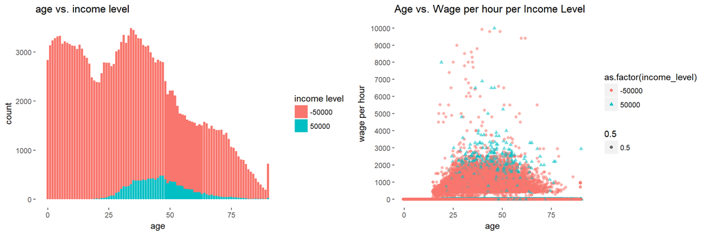

For the age variable, we can see that most of the people with income_level 1 fall into the age between *25* and *75* years, also we can notice the data has outliers at age 90 While for wage per hour, most of the people with income level 1 has a wage_per_hour between *1000* and *4000*.

### 4. Data Cleaning and Manipulation

For this step, we split each data set into 2 sets one for numeric variables and one for the categorical.

##### Missing Values

```
                       age              wage_per_hour
                         0                          0
             capital_gains             capital_losses
                         0                          0
      dividend_from_Stocks num_person_Worked_employer
                         0                          0
      weeks_worked_in_year               income_level
                         0                          0
```

```
                 class_of_worker                    industry_code
                     0.000000000                      0.000000000
                 occupation_code                        education
                     0.000000000                      0.000000000
     enrolled_in_edu_inst_lastwk                   marital_status
                     0.000000000                      0.000000000
             major_industry_code            major_occupation_code
                     0.000000000                      0.000000000
                            race                  hispanic_origin
                     0.000000000                      0.004380447
                             sex            member_of_labor_union
                     0.000000000                      0.000000000
         reason_for_unemployment    full_parttime_employment_stat
                     0.000000000                      0.000000000
                tax_filer_status     region_of_previous_residence
                     0.000000000                      0.000000000
     state_of_previous_residence          d_household_family_stat
                     0.003548463                      0.000000000
             d_household_summary                    migration_msa
                     0.000000000                      0.499671717
                   migration_reg             migration_within_reg
                     0.499671717                      0.499671717
                 live_1_year_ago                migration_sunbelt
                     0.000000000                      0.499671717
         family_members_under_18                   country_father
                     0.000000000                      0.033645244
                  country_mother                     country_self
                     0.030668144                      0.017005558
                     citizenship        business_or_self_employed
                     0.000000000                      0.000000000
fill_questionnaire_veteran_admin                veterans_benefits
                     0.000000000                      0.000000000
                            year
                     0.000000000
```

##### Near Zero Variance Variables

During the exploration step we saw a lot of variables have one level with very high frequency (around 90% of the data belong to one level) while the other levels have very low frequency ( between 1% to 4%), usually this kind of variables doesn’t have much information to offer to the predictive models, we will use nearZeroVar function to locate those variables.

*nearZeroVar* diagnoses predictors that have one unique value or predictors that have both of the following characteristics: They have very few unique values relative to the number of samples and the ratio of the frequency of the most common value to the frequency of the second most common value is large.

**Numeric Variable**

```
                     freqRatio percentUnique zeroVar  nzv
wage_per_hour         256.4292    0.62148224   FALSE TRUE
capital_gains         243.8376    0.06615779   FALSE TRUE
capital_losses        480.6314    0.05663507   FALSE TRUE
dividend_from_Stocks  155.3850    0.74076673   FALSE TRUE
```

As we saw on the exploration step those variables have a huge amount of Zero values, we will reclassify those variable to categorical with only 2 levels “zero” & “more than zero”.

**Categorical Variables**

We will drop all the variable where **nearZeroVar** is true.

```
                                 freqRatio percentUnique zeroVar  nzv
occupation_code                   11.49886   0.023556181   FALSE TRUE
enrolled_in_edu_inst_lastwk       27.12464   0.001503586   FALSE TRUE
hispanic_origin                   21.27825   0.004510758   FALSE TRUE
member_of_labor_union             11.25477   0.001503586   FALSE TRUE
reason_for_unemployment           94.92296   0.003007172   FALSE TRUE
region_of_previous_residence      37.58437   0.003007172   FALSE TRUE
state_of_previous_residence      107.20537   0.025059768   FALSE TRUE
country_father                    15.90358   0.021050205   FALSE TRUE
country_mother                    16.40722   0.021050205   FALSE TRUE
country_self                      30.68996   0.021050205   FALSE TRUE
citizenship                       13.20737   0.002505977   FALSE TRUE
business_or_self_employed         11.18504   0.001503586   FALSE TRUE
fill_questionnaire_veteran_admin 124.00439   0.001503586   FALSE TRUE
```

### 5. Machine Learning

**Performance Measure:** In this project, we will use *Area Under the Curve (AUC)* to be the main performance measure for the below reasons:

1. Usually, AUC is a very good measure to use with imbalanced data.
2. We are trying to build a model that has a good prediction for both classes (0 and 1 or <50,000 and > 50,000). in other words, we don’t have a preference or we don’t value one class accuracy over the other and AUC can do that, unlike Sensitivity for example which focus on increasing the TP rate.

**Sampling Techniques:** For imbalanced data, it’s recommended to change the dataset to be more balanced in order to use it to build our predictive model.

This change is called sampling dataset and there are a few techniques could be used, in this project, we will use over-sampling & under-sampling techniques.

We will create 2 additional sets using the mentioned methods then we will apply the classification models on the original and the new sets and evaluate the results.

**Algorithms:** We will use the below algorithms in this project:

1. Logistic Regression: we will start with a simple classification model.
2. Random Forest: often perform well on imbalanced data.
3. Naive Bayes: also a good algorithm for the imbalanced data.

**Cross Validation Stategy:** 5 fold cross validation.

We have 2 very good packages for predictive modeling CARET and MLR, however, due to the limited performance of my machine, I will use MLR (train function in CARET package consume a high portion of memory during the runtime and create huge size objects).

##### Variable Importance

Before starting with modeling, let us take a look at how important each variable to the target variable, we will use **generateFilterValuesData** function.

We can notice that education and major occupation code could provide the highest info for our model while race variable has very litter to offer here.

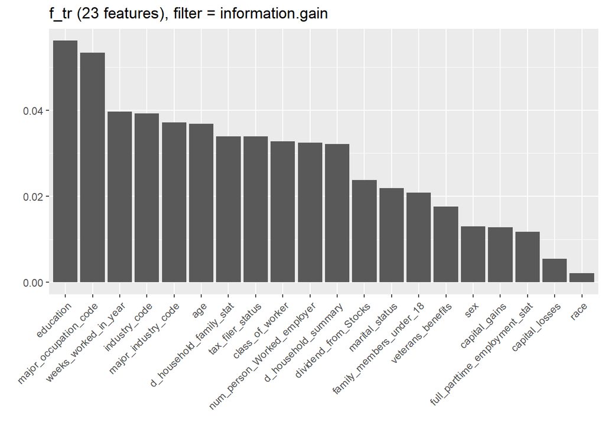

*Now let us take a look at the result of each algorithm we applied in our project*

##### Logistic Regression Model

After running the resample function we got the below warning messages:

*1: glm.fit: fitted probabilities numerically 0 or 1 occurred*

*2: In predict.lm(object, newdata, se.fit, scale = 1, type = ifelse(type == :prediction from a rank-deficient fit may be misleading*

The 1st warning could be due to separation. There are many suggested solutions for this issue, do nothing and ignore the warning, drop the variables that cause this problem but in this case, we will lose information, and finally, utilize a form of penalized regression, in fact, this is the original reason some of the penalized regression forms were developed

The 2nd warning could be due to excess of variables (this often happen in logistic regression when we have too many variables)

Anyhow, we will not go further into the logistic regression model, I just wanted to show the limitation of this model for our dataset. Let us check the naive bayes model, we may have better luck with it.

##### Naive Bayes

Below we can find the performance measures after running the resample function on the 3 sets, All 3 models almost have the same AUC *0.92*, the original task has the best tpr while under and over tasks have the best tnr  
we will train all the tasks and check their performance on the test set

```
               nb_Original  nb_Under    nb_Over
auc.test.mean   0.91463461 0.9155166 0.91505245
acc.test.mean   0.74154359 0.7732825 0.79546009
tpr.test.mean   0.73086603 0.6760176 0.66888068
tnr.test.mean   0.90292396 0.9202867 0.92300113
fpr.test.mean   0.09707604 0.0797133 0.07699887
mmce.test.mean  0.25845641 0.2267175 0.20453991
```

**Result on Test Set**

*confusion matrix for all 3 tasks (Percentage)*

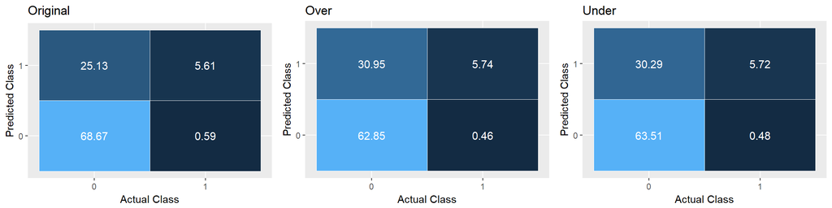

*ROC curve(fpr vs. tpr) and Precision vs. Recall*

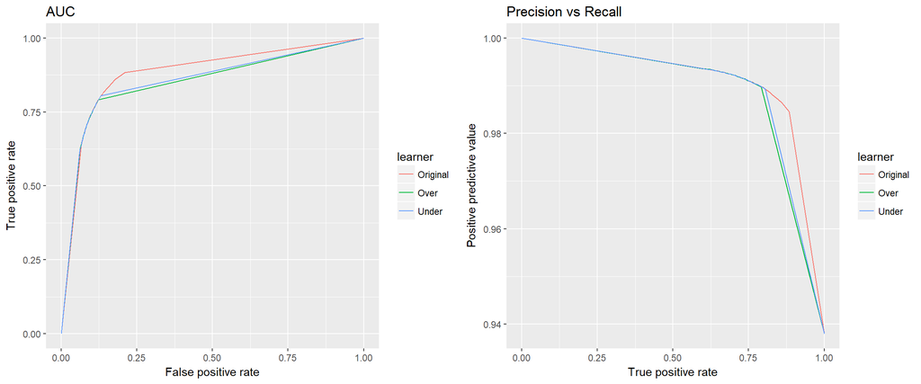

It seems original model is slightly better than other models (especially with tpr measure). We will consider the original model as the best one on the naive bayes

```
       auc        acc        tpr        tnr        fpr       mmce
0.91678730 0.74284798 0.73210011 0.90543162 0.09456838 0.25715202
```

##### Random Forest Model

Below we can find the performance measures after running the resample function on the 3 sets, original task performs bad for tnr *0.37*, over-sampling has very high auc & tnr *0.99* while under-sampling has a good auc,tpr & tnr with *0.94*, *0.88* & *0.85* respectively

We will train both under and over tasks to compare their performance on the test set as I suspect overfitting for the over-sampling task in one of the classes

```
               rf_Original  rf_Under    rf_Over
auc.test.mean   0.93667972 0.9385116 0.99039842
acc.test.mean   0.95055709 0.8642268 0.95326265
tpr.test.mean   0.98867699 0.8754408 0.91977706
tnr.test.mean   0.37441541 0.8472778 0.98700264
fpr.test.mean   0.62558459 0.1527222 0.01299736
mmce.test.mean  0.04944291 0.1357732 0.04673735
```

**Result on Test Set**

*confusion matrix (Percentage)*

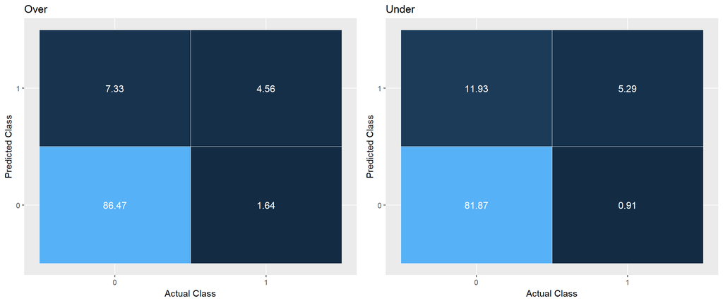

*ROC curve(fpr vs. tpr) and Precision vs. Recall*

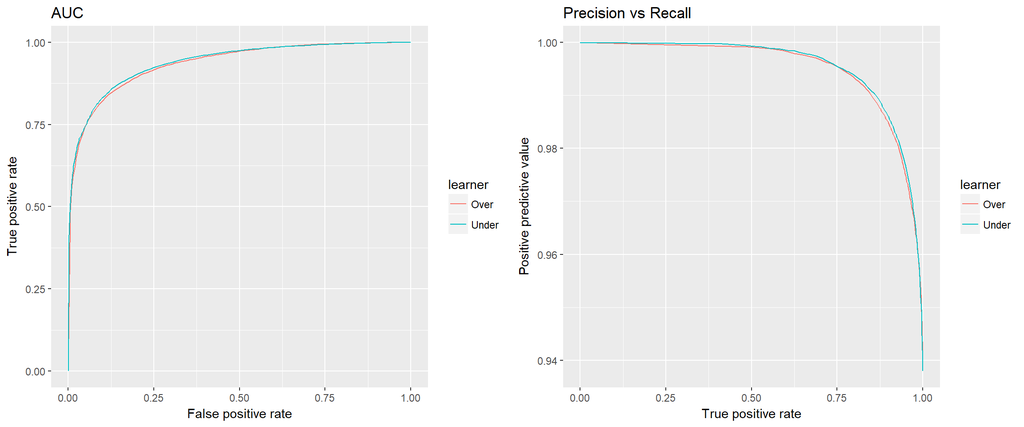

Both models have almost same performance measures in the test set, but over-sampling have *0.99* AUC on the training set and *0.94* on the test set while under-sampling maintains his AUC performance on both sets *0.94* which indicate that under-sampling is the more reliable model.

*Best forest model model performance measures*

```
      auc       acc       tpr       tnr       fpr      mmce
0.9390310 0.8715844 0.8728093 0.8530553 0.1469447 0.1284156
```

##### Comparison

*Naive Bayes vs. Random Forest*

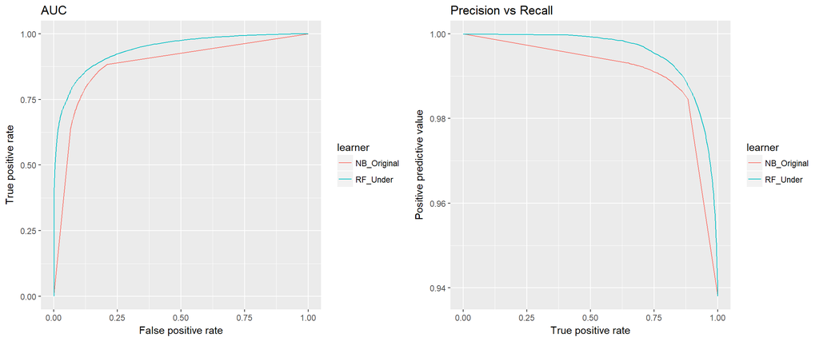

Random forest under-sampling model is the best model in this project with **0.94 auc** comparing to the naive bayes original model with *auc 0.92*, therefore, we can say that our best model in this project is the random forest under-sampling.

##### Room for Improvement?

Actually, there are some steps that we can do to improve our model result but due to the limitation of my machine performance, I couldn’t run those steps. Below you can find 2 examples to improve our random forest under-sampling model

**1. Feature Selection**

We can use makeFeatSelControlRandom and selectFeatures functions to chose features that maximaze the auc measure as follow:

ctrl <- makeFeatSelControlRandom(maxit = 5)

randF_SF <- selectFeatures(rf_learner,tr_Under,res_Mod, measures = list(auc,acc,tpr,tnr),control = ctrl)

**2. Model Tuning**

Also, we can tune the parameters in the model using tuneParams function

*Search for hyperparameters*  
rf_MP <- makeParamSet(makeIntegerParam(“minsplit”,lower = xx, upper = xx), makeIntegerParam(“minbucket”, lower = xx, upper = xx), makeNumericParam(“cp”, lower = xx, upper = xx))

*do a grid search*  
rf_C <- makeTuneControlGrid()

*hypertune the parameters*

stune <- tuneParams(learner = rf_learner, resampling = res_Mod, task = tr_Under, par.set = rf_MP, control = rf_C, measures = auc)